# l7_quant2_ii_en

## Cleaning and coding the data

**Step 1. Packages, reading, and accents**

```r
library(tidyverse)   # ggplot2, dplyr, tidyr, forcats, stringr, purrr...
library(haven)       # to read Stata files (.dta)
library(scales)      # to format percentages in the graphs

# 1. READ THE DATA -------------------------------------------------------
barometro <- read_dta("03_Datos_octubre_2026.dta", encoding = "latin1")

# 2. FIX THE ACCENTS (the file mixes encodings) -----------------
arregla <- function(x) {
  x <- iconv(x, from = "UTF-8", to = "latin1")
  Encoding(x) <- "UTF-8"
  x
}
for (v in names(barometro)) {
  attr(barometro[[v]], "label") <- arregla(attr(barometro[[v]], "label"))
  etiquetas_valor <- attr(barometro[[v]], "labels")
  if (!is.null(etiquetas_valor)) {
    names(etiquetas_valor) <- arregla(names(etiquetas_valor))
    attr(barometro[[v]], "labels") <- etiquetas_valor
  }
}
```

**Step 2. Short labels for the question batteries**

```r
# 3. SHORT LABELS FOR THE QUESTION BATTERIES -----------------------
# The file's labels are truncated to ~80 characters, so we
# write them by hand based on the questionnaire (variable name = label)
etiq_p8 <- c(p8_1 = "Housing", p8_2 = "Inflation and cost of living",
             p8_3 = "Unemployment", p8_4 = "Climate change",
             p8_5 = "Inequality and poverty", p8_6 = "Immigration",
             p8_7 = "Armed conflicts", p8_8 = "Artificial Intelligence",
             p8_9 = "The country's economic situation")

etiq_p11 <- c(p11_1 = "Purchase price", p11_2 = "Rental price",
              p11_3 = "Lack of housing", p11_4 = "Low wages and precarious jobs",
              p11_5 = "Demands from landlords/banks", p11_6 = "Tourist apartments",
              p11_7 = "Investment funds", p11_8 = "Other", p11_9 = "Don't know")

etiq_p22 <- c(p22_1 = "Expand social housing",
              p22_2 = "Public construction of private housing",
              p22_3 = "Tax advantages for small landlords",
              p22_4 = "Non-payment insurance and legal assistance",
              p22_5 = "Raise property tax (IBI) on empty homes",
              p22_6 = "Ban tourist apartments in residential buildings",
              p22_7 = "Cap on annual rent increases",
              p22_8 = "Regulate rental prices",
              p22_9 = "Limit on number of properties per owner",
              p22_10 = "Monthly rental vouchers",
              p22_11 = "Postpone evictions of vulnerable people",
              p22_12 = "Ban evictions of vulnerable people")
```

**Step 3. A function to convert and remove the “Don’t know”s**

```r
# 4. FUNCTION: labels -> factor, and "Don't know" -> NA ------------------------
a_factor <- function(x) {
  as_factor(x) %>%
    fct_na_level_to_value(extra_levels = c("No lo sé", "Prefiero no contestar"))
}
```

**Step 4. Clean and code (the long step)**

```r
# 5. CLEAN AND CODE ---------------------------------------------------
d <- barometro %>%
  mutate(
    # a) Sociodemographic variables: labeled number -> factor
    edad         = as.numeric(edad),
    sexo         = as_factor(sexo),
    edad_r       = as_factor(edad_r),
    clase_social = as_factor(clase_social_r),
    ccaa         = as_factor(ccaa) %>% fct_drop() %>%     # Ceuta and Melilla: 0 cases
      fct_recode("Asturias"   = "Asturias, Principado de",
                 "Baleares"   = "Balears, Illes",
                 "Madrid"     = "Madrid, Comunidad de",
                 "Murcia"     = "Murcia, Región de",
                 "Navarra"    = "Navarra, Comunidad Foral de",
                 "La Rioja"   = "Rioja, La",
                 "Valencia"   = "Comunitat Valenciana",
                 "Castilla-La Mancha" = "Castilla - La Mancha"),

    # b) 0-10 scales: 99 means "Don't know," so it becomes NA
    across(c(p2, p5_1:p5_6, p7), ~ na_if(as.numeric(.x), 99)),

    # c) Questions with categories: factor and "Don't know" -> NA
    across(c(p8_1:p8_9, p9, p10, p14, p20, p21, p22_1:p22_12, p24, p36), a_factor),

    # d) Housing tenure: we group 7 categories into 5
    regimen = case_when(
      p27 %in% c(1, 3) ~ "Propiedad sin hipoteca",
      p27 == 2         ~ "Propiedad con hipoteca",
      p27 %in% c(4, 5) ~ "Alquiler",
      p27 == 6         ~ "Con familia",
      p27 == 7         ~ "Otra situación"
    ) %>% factor(levels = c("Propiedad sin hipoteca", "Propiedad con hipoteca",
                            "Alquiler", "Con familia", "Otra situación")),

    # e) Vote: we group the 23 codes of p3
    voto = case_when(
      p3 == 1          ~ "PSOE",
      p3 == 2          ~ "PP",
      p3 == 3          ~ "Vox",
      p3 == 4          ~ "Sumar",
      p3 == 5          ~ "Podemos",
      p3 %in% 6:18     ~ "Otros partidos",
      p3 %in% 19:21    ~ "Blanco, nulo o abstención",
      p3 %in% 22:23    ~ NA_character_            # Don't know / No answer
    ) %>% factor(levels = c("PSOE", "PP", "Vox", "Sumar", "Podemos",
                            "Otros partidos", "Blanco, nulo o abstención")),

    # f) Ideology recoded into 3 groups
    ideologia_grupo = case_when(
      p7 <= 3 ~ "Izquierda",
      p7 <= 6 ~ "Centro",
      p7 >= 7 ~ "Derecha"
    ) %>% factor(levels = c("Izquierda", "Centro", "Derecha"))
  ) %>%
  # g) Names that are easier to understand (new = old)
  rename(ideologia = p7, prob_voto = p2,
         prob_psoe = p5_1, prob_pp = p5_2, prob_vox = p5_3,
         prob_sumar = p5_4, prob_podemos = p5_5, prob_salf = p5_6,
         acceso_vivienda = p10, preocupa_dejar_vivienda = p36)
```

**Step 5. Multiple response (p11): `NA` becomes 0**

```r
# Checked box = 1, blank = NA. Here NA means "not checked," so it becomes 0
d <- d %>%
  mutate(across(starts_with("p11_"), ~ if_else(is.na(.x), 0, 1)))
```

**Step 6. Check that it worked**

```r
dim(d)                       # 2,000 rows, and the same columns plus the new ones
```

```
[1] 2000  101
```

```r
d %>% count(voto)            # How many NAs are there? These are the "Don't know"s and "No answer"s
```

```
# A tibble: 8 × 2
  voto                          n
  <fct>                     <int>
1 PSOE                        446
2 PP                          396
3 Vox                         369
4 Sumar                        87
5 Podemos                      53
6 Otros partidos              222
7 Blanco, nulo o abstención   204
8 <NA>                        223
```

```r
d %>% count(ideologia_grupo) # 155 NA: those who answered 99 on p7
```

```
# A tibble: 4 × 2
  ideologia_grupo     n
  <fct>           <int>
1 Izquierda         580
2 Centro            766
3 Derecha           499
4 <NA>              155
```

```r
summary(d$ponde)             # the weight: mean 1, reasonable min and max
```

```
   Min. 1st Qu.  Median    Mean 3rd Qu.    Max.
 0.6206  0.8173  0.9237  1.0000  1.0853  2.9001
```

## The grammar of graphics

- *ggplot2* is a structured, layered grammatical system, based on Wilkinson’s (2005) theory.
- The grammar of graphics provides an almost universal way to produce practically every form of data visualization, expressing its attributes and relationships.
- It lets us break graphs down into distinct tasks, to handle and organize them better.
- **Key idea to get started.** Just like a sentence is built with a subject, verb, and complements, a graph is built by **adding layers** with `+`.

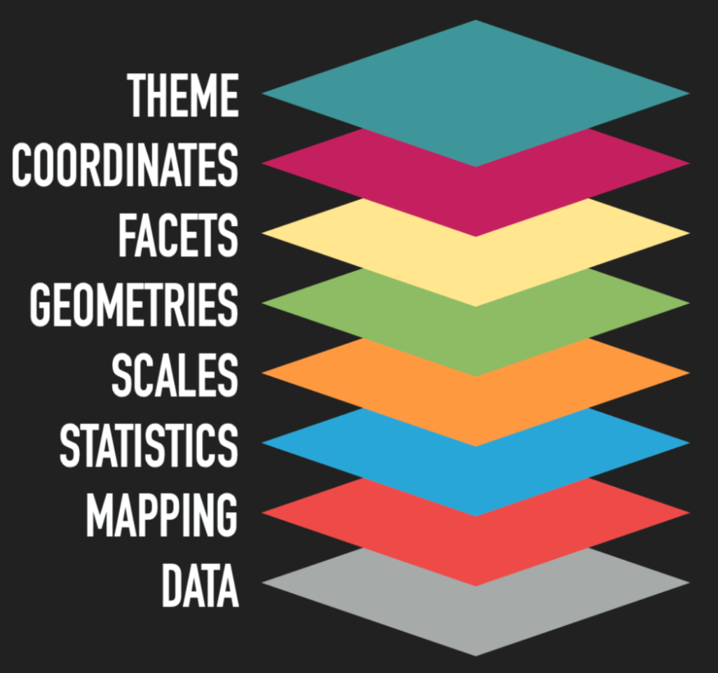

## The basic grammar of graphs (I)

> A graph is a way of mapping `data` to `geom`etric objects that capture their `aes`thetic attributes.

In `ggplot2` we have 4 essential elements:

- `data`: the dataset we want to plot
- `aes`: the **aesthetics**, that is, which variable goes in each dimension (x, y) and which variable controls color, shape, size, or transparency
- `geom`: the geometric shape that represents the data (points, lines, bars, etc.)
- `+`: the joining of layers

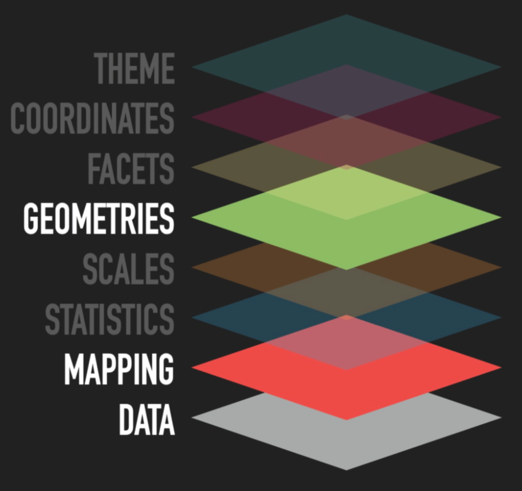

## The full layers of a graph

Beyond the 4 essential elements, `ggplot2` has **optional** layers that we’ll go through in this order:

| Layer | What it decides | Functions | Example with the Barometer |
| --- | --- | --- | --- |
| **Data** | Which table we use | `ggplot(data = )` | `d` |
| **Aesthetics** | Which variable goes to each dimension | `aes()` | `x = ideologia, y = prob_vox, color = sexo` |
| **Geometries** | What shape is used to draw | `geom_*()` | `geom_point()`, `geom_boxplot()`, `geom_col()` |
| **Statistics** | What calculation is done before drawing | `stat_*()` | count, average, smooth |
| **Position** | How overlapping bars or points are arranged | `position =` | `"stack"`, `"dodge"`, `"fill"`, `"jitter"` |
| **Scales** | How a data value is translated into an axis, color, or size | `scale_*_*()` | `scale_y_continuous(labels = percent)` |
| **Coordinates** | The “canvas” (flipped axes, zoom) | `coord_*()` | `coord_flip()`, `coord_cartesian()` |
| **Facets** | Splitting into panels | `facet_wrap()`, `facet_grid()` | `facet_wrap(~ clase_social)` |
| **Labels and theme** | Titles, background, typography | `labs()`, `theme_*()`, `theme()` | `theme_minimal()` |

The general template is always the same:

```r
ggplot(data = <DATA>, mapping = aes(<AESTHETICS>)) +
  <GEOM>() +
  <STAT, POSITION, SCALES, COORDINATES, FACETS, LABELS AND THEME>
```

## The basic grammar of graphs (II)

- Data
- Graph A
- Graph B
- Graph C
- Graph D

The data is already loaded and clean in the object `d`. Each row is a person and each column, a variable.

```r
d %>%
  select(id, sexo, edad, ccaa, ideologia, prob_pp, prob_vox) %>%
  head(4)
```

```
# A tibble: 4 × 7
     id sexo    edad ccaa      ideologia prob_pp prob_vox
  <dbl> <fct>  <dbl> <fct>         <dbl>   <dbl>    <dbl>
1     1 Hombre    34 Madrid            7       6        8
2     2 Mujer     66 Madrid            3       7        0
3     3 Hombre    53 Valencia          5       5        5
4     4 Hombre    62 Andalucía         1       0        0
```

`prob_pp` and `prob_vox` are the probability (0 to 10) of voting for each party. `ideologia` goes from 0 (left) to 10 (right).

`ggplot()` only sets up the canvas and the axes. **It still draws nothing**, because the geometry is missing.

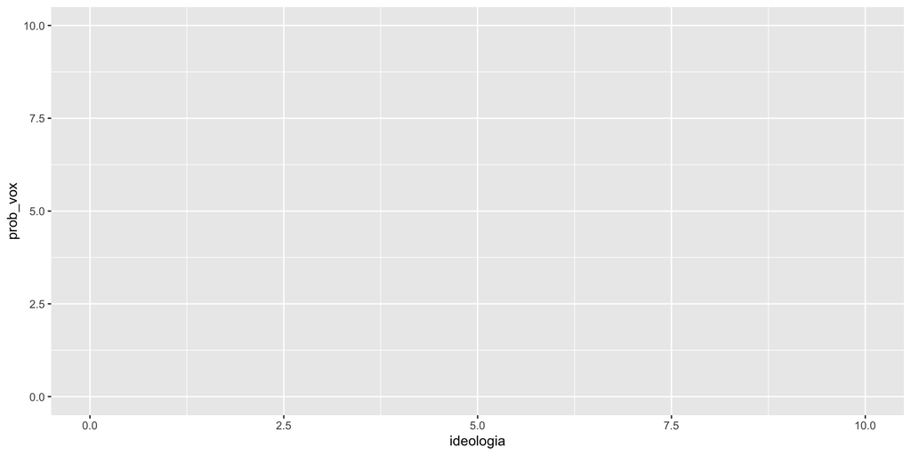

```r
ggplot(data = d,
       mapping = aes(
         x = ideologia,
         y = prob_vox
       ))
```

We add a layer with `+ geom_point()`. Now a point for each person does appear.

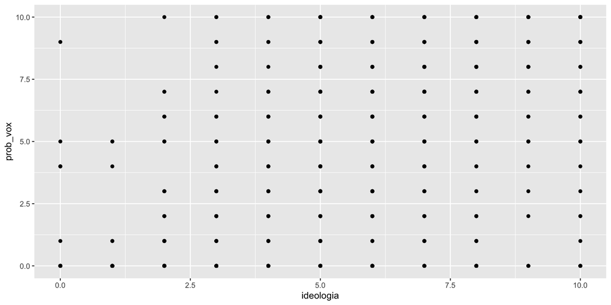

```r
ggplot(data = d,
       mapping = aes(
         x = ideologia,
         y = prob_vox
       )) +
  geom_point()
```

**Note**

Why does it look like there are few points? Because many people gave **exactly the same answer** and the points overlap (*overplotting*). If R warns about `Removed rows containing missing values`, those are the people with `NA` in one of the two variables.

The `aes()` can also go **inside the geom**. Then it only applies to that layer.

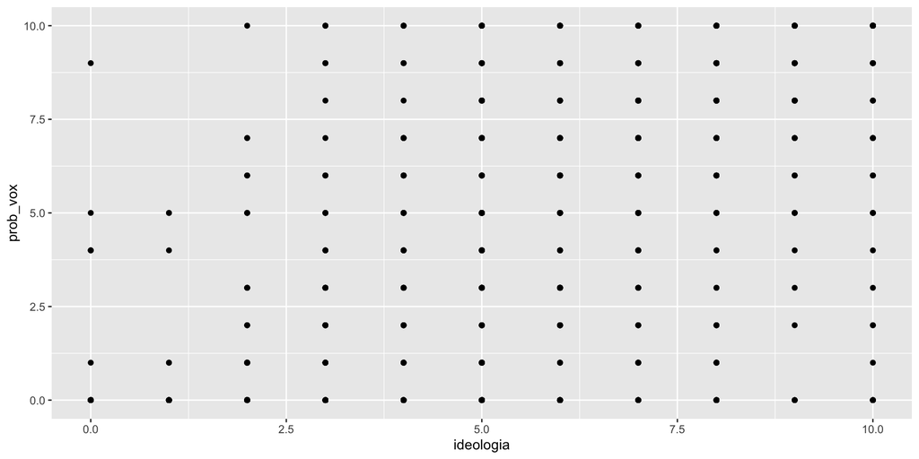

```r
# The aesthetic mapping can also be done locally
# (in the geom) instead of for the whole graph
ggplot(data = d) +
  geom_point(mapping = aes(
         x = ideologia,
         y = prob_vox))
```

A very similar geometry that **spreads the points out a bit** so they’re all visible:

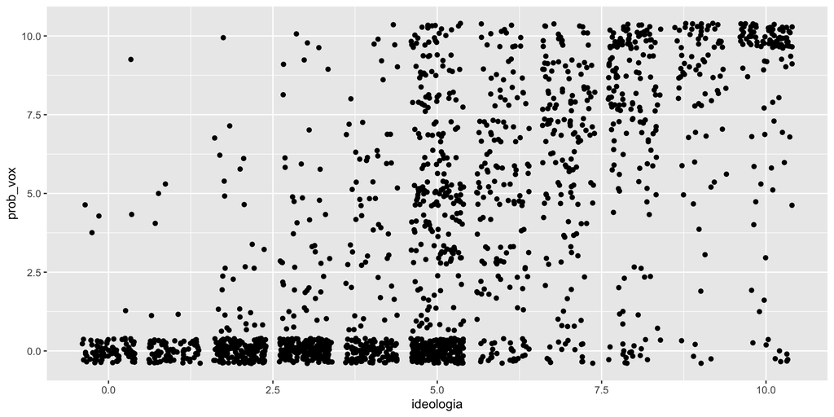

```r
ggplot(data = d) +
  geom_jitter(mapping = aes(
         x = ideologia,
         y = prob_vox))
```

## A bit more about aesthetics

- Graph A
- Graph B
- Graph D

A **categorical** variable in `color` gives one color per category.

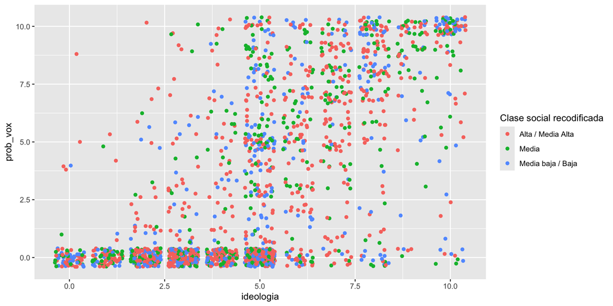

```r
ggplot(data = d) +
  geom_jitter(mapping = aes(x = ideologia,
                            y = prob_vox,
                            color = clase_social))
```

Inside `aes()` we can also write a **condition**. R creates a `TRUE` / `FALSE` variable on the fly.

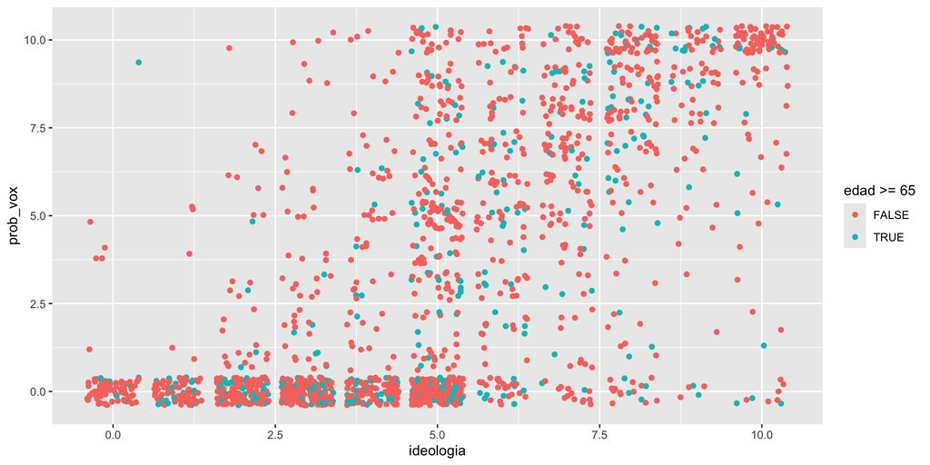

```r
ggplot(data = d) +
  geom_jitter(mapping = aes(x = ideologia,
                            y = prob_vox,
                            color = edad >= 65))
```

Other aesthetics: `shape` (shape), `size` (size), and `alpha` (transparency). We fix `alpha` and `size` so the clustering is visible.

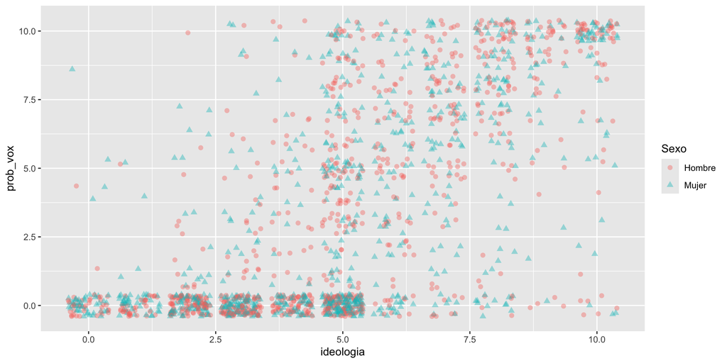

```r
ggplot(data = d) +
  geom_jitter(aes(x = ideologia,
                  y = prob_vox,
                  color = sexo,
                  shape = sexo),
              size = 2, alpha = .4)
```

## More geometries

- Graph A
- Graph B
- Graph C
- Graph D
- Graph E

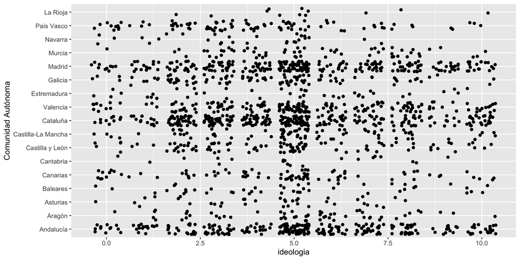

```r
ggplot(data = d) +
  geom_jitter(aes(x = ccaa, y = ideologia)) +
  coord_flip()
```

With many categories, the box plot summarizes each group: median, quartiles, and outliers.

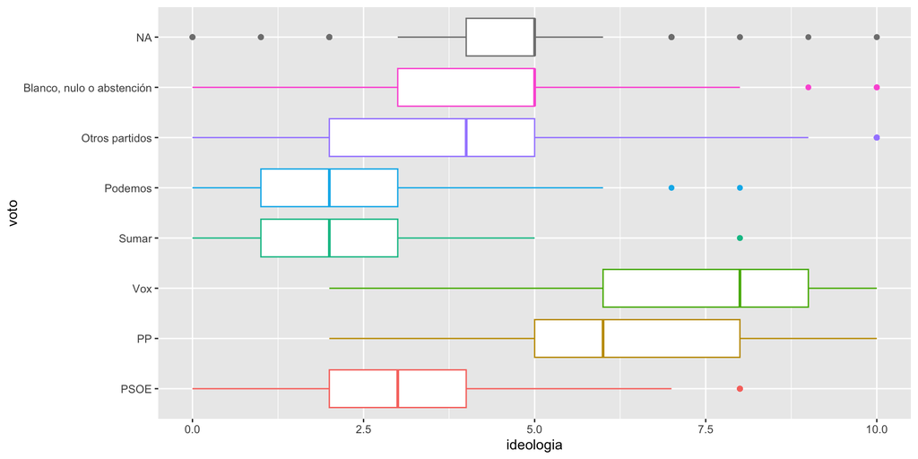

```r
ggplot(data = d) +
  geom_boxplot(aes(x = ideologia, y = voto, color = voto)) +
  theme(legend.position = "none")
```

The violin plot also shows **where the responses cluster**.

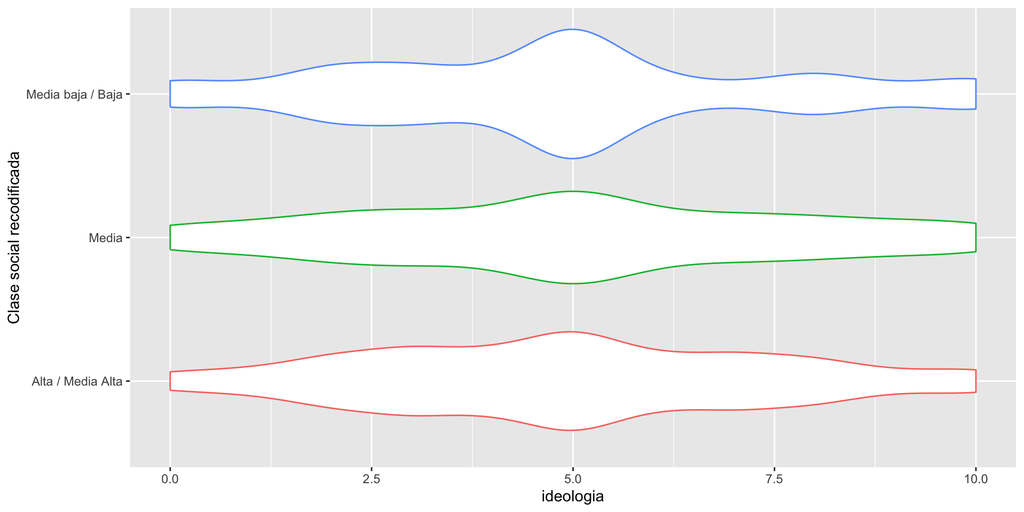

```r
ggplot(data = d) +
  geom_violin(aes(x = ideologia, y = clase_social, color = clase_social)) +
  theme(legend.position = "none")
```

With **a single quantitative variable**, the histogram groups values into bins. `binwidth` is the width of the bin.

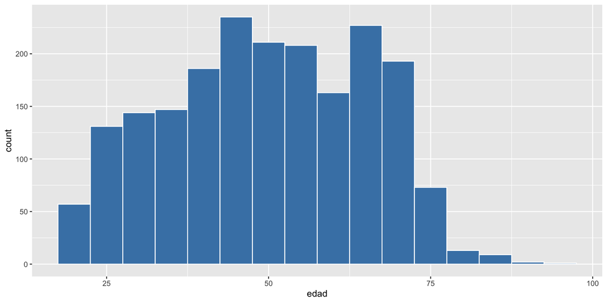

```r
ggplot(data = d) +
  geom_histogram(aes(x = edad), binwidth = 5,
                 fill = "steelblue", color = "white")
```

With **a single categorical variable**, the bars count cases.

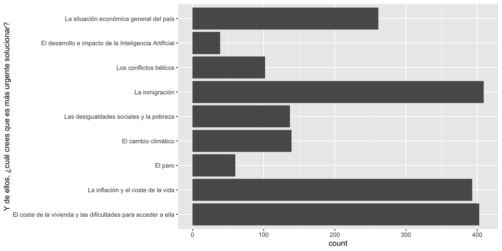

```r
d %>%
  filter(!is.na(p9)) %>%
  ggplot() +
  geom_bar(aes(y = p9))
```

## Which geom_ do I use?

First question: **what type of variable do I have?**

| No. of variables | Type of variable(s) | Common geom_ | Example with the Barometer |
| --- | --- | --- | --- |
| One | Categorical | `geom_bar()` | `aes(y = acceso_vivienda)` |
| One | Quantitative | `geom_histogram()`, `geom_density()`, `geom_boxplot()` | `aes(x = edad)` |
| Two | Categorical vs. categorical | `geom_bar()` (`fill`/`dodge` position), `geom_count()`, `geom_tile()` | `aes(x = clase_social, fill = acceso_vivienda)` |
| Two | Categorical vs. quantitative | `geom_boxplot()`, `geom_violin()`, `geom_jitter()`, `stat_summary()` | `aes(x = ideologia, y = voto)` |
| Two | Quantitative vs. quantitative | `geom_point()`, `geom_jitter()`, `geom_smooth()` | `aes(x = edad, y = prob_vox)` |

**Tip**

To know whether a variable is categorical or quantitative, ask `class(d$ideologia)`. `numeric` is usually quantitative. `factor` is categorical. A 0 to 10 scale is numeric but takes few values, which is why it often needs `geom_jitter()`.